# PSTAT100 Data Science Concepts and Analysis

## Assignment 1

**Author: Aldo Nunez** **Date: 04-19-26**

#### Submission Instructions

This assignment will be **due for submission on Sunday April 19th at 11:59PM**. Please ensure you submit a `.pdf` file to Canvas by the posted time, no other file types will be accepted. Please see the course website for some information regarding exporting Jupyter notebooks to pdf, and if you are having exporting problems discuss them with a member of the teaching staff in their office hours.

## Introduction

In this assignment you will be performing a simple descriptive analysis exploring association between adverse childhood experiences, health perceptions, tobacco use, and depressive disorders. In this assignment your aim should be to practice critical thinking about data collection, apply basic descriptive analysis in `python` and develop your communication and technical writing skills.

Below is a broad summary of the methods and skills you will be implementing:

- **Critical thinking about data collection (Week 1):**
  - Reading and understanding the BRFSS data documentation.
  - Identifying sampled units, variables measured and the sampling frame.
  - Assessing study design, data integrity, and scope of inference.
- **Data manipulation and preparation (Week 2):**
  - Data importing and inspection.
  - Data frame manipulation (slicing, index manipulation, grouping and aggregation).
  - Data preparation (missingness, duplicates, labelling).
- **Exploratory data analysis (Week 3):**
  - Summary statistics.
  - Visualizations.
- **Communication:**
  - Clear and concise discussion of methodology and results.
  - Guide to report structuring and writing style.

In this notebook we will make use of the following `python` libraries:

```python
# Required libraries
!pip install altair missingno
import numpy as np
import pandas as pd
import altair as alt
import matplotlib.pyplot as plt
import missingno as msno
```

## Background

The [Behavioral Risk Factor Surveillance System](https://www.cdc.gov/brfss/index.html) (BRFSS) is a long-term effort administered by the CDC to collect data on behaviors affecting physical and mental health, past and present health conditions, and access to healthcare among U.S. residents. The BRFSS comprises telephone surveys of U.S. residents conducted annually since 1984; in the last decade, over half a million interviews have been conducted each year. This is the largest such data collection effort in the world, and many countries have developed similar programs. The objective of the program is to support monitoring and analysis of factors influencing public health in the United States.

Each year, a standard survey questionnaire is developed that includes a core component comprising questions about: demographic and household information; health-related perceptions, conditions, and behaviors; substance use; and diet. Trained interviewers in each state call randomly selected telephone (landline and cell) numbers and administer the questionnaire; the phone numbers are chosen so as to obtain a representative sample of all households with telephone numbers.

The raw BRFSS survey data is submitted to the CDC for processing and compilation into a single dataset. In the process, a number of 'derived variables' are calculated based on questionnaire responses and appended to the dataset. A simple example is weight in kg, derived from respondents' weights reported in pounds.

Take a moment to [read about the 2024 survey here](https://www.cdc.gov/brfss/annual_data/annual_2024.html) (follow the link!) and review the publicly available information. This includes data and documentation pertaining to sampling methodology, questionnaires, variable coding, derived variables, and response rates.

## 1. Data

### 1.1 Data Import

We begin by importing the 2024 BRFSS data from a compressed CSV file and perform some basic qualitative assessments including:

- Examining the imported data.
- Checking your understanding of the data format.
- Investigating the data collection procedure.

Throughout the process keep thinking back to the Data Science Lifecycle and how it is guiding the structure of this report. These initial checks and background study into how the data was generated are essential steps in data analysis. You should make them standard practice in your work. Investigating the data collection procedure is especially important. It is professionally irresponsible to analyze data without knowing where they came from, and collection protocols (known as a *sampling design*) can have strong implications for whether findings can be replicated and whether they might be biased.

The data provided by the CDC website is provided in XPT transport format which has been converted to a compressed `.csv` file with extension `csv.gz`. For this assignment, you'll work with just a few of the 300+ variables, namely sex, age, general health self-assessment, smoking status, depressive disorder, and adverse childhood experiences (ACEs). The names of these variables as they appear in the raw dataset are stored in the list `selected_variables`.

For those who are interested in the code used to convert this data it has been included below.

```python
# WARNING: This cell takes a long time to run.
# df = pd.read_sas('data/LLCP2024.XPT', format='xport', encoding='utf-8')
# df.to_csv('data/brfss_2024.csv.gz', index=False, compression='gzip')
```

We begin by loading the data using `pd.read_csv()`, specifying the compression style `gzip`. We note that this specification is not technically needed as `pandas` is able to detect the compression style automatically but it is included here for clarity.

```python
brfss = pd.read_csv('data/brfss_2024.csv.gz', compression='gzip')
```

**‼️ Problem**

#### Q1 Data Inspection

1. Print the shape (number of rows and columns) of the raw data and comment on your findings. Does this match what you would expect given information from the documentation ([follow this link](https://www.cdc.gov/brfss/annual_data/all_years/states_data.htm))?
2. Using `pandas` define a subset of the data named `brfss` that only contains the columns specified in `selected_vars`.
3. Confirm that you were successful by printing the shape of your data subset and inspecting the first few rows of the new data set.
4. Discuss what each row (observation) of the `brfss` data frame represents?
5. Discuss what each column (variable) of the `brfss` data frame represents?

**Solution:**

```python
print("Raw data shape: ", brfss.shape) #it does match documentation nums

selected_vars = ['_SEX', '_AGEG5YR', 'GENHLTH', 'ACEPRISN', 'ACEDRUGS',
                 'ACEDRINK', 'ACEDEPRS', 'ADDEPEV3', '_SMOKER3', '_LLCPWT'
]

brfss = brfss[selected_vars]

print("subset shape: ", brfss.shape)
brfss.head()

# row = individual person
# columns = demographic characteristics, general health, smoking status,
# depressive disorder ,adverse childhood experience
```

```
Raw data shape:  (457670, 301)
subset shape:  (457670, 10)
```

|  | _SEX | _AGEG5YR | GENHLTH | ACEPRISN | ACEDRUGS | ACEDRINK | ACEDEPRS | ADDEPEV3 | _SMOKER3 | _LLCPWT |
| --- | --- | --- | --- | --- | --- | --- | --- | --- | --- | --- |
| 0 | 2.0 | 12.0 | 3.0 | NaN | NaN | NaN | NaN | 2.0 | 4.0 | 261.525511 |
| 1 | 1.0 | 13.0 | 1.0 | NaN | NaN | NaN | NaN | 2.0 | 3.0 | 307.169688 |
| 2 | 1.0 | 8.0 | 2.0 | NaN | NaN | NaN | NaN | 2.0 | 1.0 | 2939.862806 |
| 3 | 1.0 | 13.0 | 1.0 | NaN | NaN | NaN | NaN | 2.0 | 4.0 | 153.584844 |
| 4 | 1.0 | 6.0 | 3.0 | NaN | NaN | NaN | NaN | 2.0 | 4.0 | 1229.623036 |

### 1.2 Data Understanding

**It is essential to devote effort to understanding how data were obtained before taking any further steps, no matter how basic those steps might be.** Without adequate background, it is easy to miss potential complications affecting how an analyst should engage with a project. To name a few examples:

- Convenience or haphazard sampling (*e.g.*, surveying my neighbors) could entail that patterns in the data are non-generalizable, as they may be difficult or impossible to replicate if the data are collected anew.
- There may be sources of bias inherent in measurements (*e.g.*, failing to properly calibrate lab equipment) that could produce misleading results.
- Ethical issues (*e.g.*, data from animal experiments, conflicts of interest, sensitive user information, etc.) may require withdrawal from a project for personal reasons or demand extra caution to protect subject privacy.

These matters are never evident from data itself, and require critical qualitative assessment of data collection procedures.

**‼️ Problem**

#### Q2 Data Understanding

Skim the [overview documentation](https://www.cdc.gov/brfss/annual_data/2024/pdf/Overview_2024-508.pdf) for the 2024 BRFSS data. Focus specifically the 'Background' and 'Data Collection' sections, and read between the technical information (don't worry if you don't understand everything in the documentation), and answer the following questions:

1. Who does an interviewer speak to in each household.
2. What criteria must a person meet to be interviewed.
3. Who can't possible appear in the survey. Give two examples.
4. Who conducts the interviews and how long does the core portion of a typical interview last?
5. How would you describe the study population (i.e. all individuals who could possibly be sampled)?
6. Does the data contain any identifying information on respondents.

**Solution:**

1. The interviewer speaks to one randomly selected adult in each household, specifically, the adult with the most recent bday
2. To be interviewed, a person must be a legal adult and a resident of the house being contacted. The house must have a phone.
3. Children under 18 years old and people who don't have access to a telephone
4. Trained interviewers employed or contracted by each state health department conduct the interviews. The core portion of a typical interview lasts 16-18 minutes
5. The study population consists of all non-institutionalized adults residing in US househols that have telephone access
6. No, the dataset does not contain indentifying information on respondents.

Now that you have a good understanding of how the data are formatted and how they were collected, you can start engaging with the dataset in an informed way.

With a narrowed set of variables to focus on, we aim to make a data dictionary noting clearly the meaning of each variable and how its measurements are recorded in the dataset (*e.g.*, text, numeric/continuous, numeric/categorical, logical, etc.). **This is yet another essential step in any analysis**. It is often useful, and therefore good practice, to include a brief description of each variable at the outset of any reported analyses, both for your own clarity and for that of any potential readers.

**‼️ Problem**

#### Q3 Data Dictionary

Open the [2024 BRFSS codebook](https://www.cdc.gov/brfss/annual_data/2024/zip/codebook24_llcp-v2-508.zip) in your browser and use text searching to locate each of the variable names of interest. Read the codebook entries and fill in the second column in the table below with a one-sentence description of each variable identified in `selected_vars`.

**Solution:**

[output not shown]

[output not shown]

In order to ensure reproducibility we set the `random_state` argument in the `sample()` function to a random number. This ensure that every time the cell is run, the same subsample is drawn.

```python
# randomly sample 10k records
brfss_samp = brfss.sample(
    n = 5000,
    random_state = 32221,
    replace = False,
    weights = '_LLCPWT'
    )
```

**Aside.** Notice also that *sampling weights* provided with the dataset are used to draw a weighted sample. Some respondents are more likely to be selected than others from the general population of U.S. adults with phone numbers, so the BRFSS calculates derived weights that represent the probability that the respondent is included in the survey. This is a somewhat sophisticated calculation, however if you're interested, you can read about how these weights are calculated and why in the overview documentation you used to answer the questions above. We use them in drawing the subsample so that we get a representative sample of U.S. adults with phone numbers.

### 1.3 Data Preparation

Here you will perform a rudimentary data preparation procedure

Here you'll **tidy** up the subsample, performing the following steps:

- Inspecting for missingness.
- Inspecting for duplicates.
- Replacing coded values of question responses with responses.
- Defining new variables based on existing ones.
- Renaming columns.

The objective of this section is to produce a clean version of the dataset that is well-organized, intuitive to navigate, and ready for analysis.

Upon our initial inspection of the data we noticed that several variables contain missing data. We wish to quantify the proportion of missingness and produce some visualizations to help us understand it.

**‼️ Problem**

#### Q4 Missingness

1. Use `is.na()` and `mean()` to compute the proportion of missing values for each variable.
2. Using code from the lecture slides produce the following figures:
   - Missingness bar plot.
   - Missingness matrix plot.

Briefly comment on what you see from your results.

**Solution:**

```
Proportion missing per variable:
_SEX        0.0000
_AGEG5YR    0.0000
GENHLTH     0.0000
ACEPRISN    0.8842
ACEDRUGS    0.8840
ACEDRINK    0.8840
ACEDEPRS    0.8838
ADDEPEV3    0.0000
_SMOKER3    0.0000
_LLCPWT     0.0000
dtype: float64
```

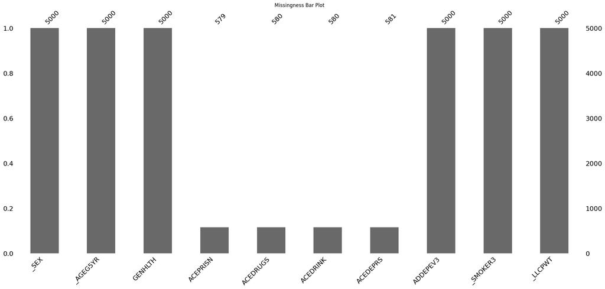

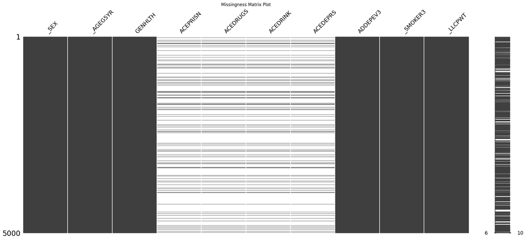

```python
missing_props = brfss_samp.isna().mean()
print("Proportion missing per variable:")
print(missing_props)


msno.bar(brfss_samp)
plt.title("Missingness Bar Plot")
plt.show()


msno.matrix(brfss_samp)
plt.title("Missingness Matrix Plot")
plt.show()
```

Now notice that the variable entries are coded numerically to represent certain responses. These should be replaced by more informative entries. We can use the codebook to determine which number means what, and replace the values accordingly.

The cell below creates a copy of our sample data called `brfss_samp_enc`, replacing the numeric values for `_AGEG5YR` by their meanings, illustrating how to use `.replace()` with a dictionary to convert the numeric coding to interpretable values. The basic strategy is:

1. Store the variable coding for `VAR` as a dictionary `var_codes`.
2. Use `.replace({'VAR': var_codes})` to modify values.

If you need additional examples, check the [pandas documentation](https://pandas.pydata.org/docs/reference/api/pandas.DataFrame.replace.html) for `.replace()`.

```python
# dictionary representing variable coding
age_codes = {
    1: '18-24', 2: '25-29', 3: '30-34',
    4: '35-39', 5: '40-44', 6: '45-49',
    7: '50-54', 8: '55-59', 9: '60-64',
    10: '65-69', 11: '70-74', 12: '75-79',
    13: '80+', 14: 'Unsure/refused/missing'
}

# recode age categories
brfss_samp_enc = brfss_samp.replace({'_AGEG5YR': age_codes})

# check result
brfss_samp_enc.head()
```

|  | _SEX | _AGEG5YR | GENHLTH | ACEPRISN | ACEDRUGS | ACEDRINK | ACEDEPRS | ADDEPEV3 | _SMOKER3 | _LLCPWT |
| --- | --- | --- | --- | --- | --- | --- | --- | --- | --- | --- |
| 215595 | 2.0 | 80+ | 4.0 | NaN | NaN | NaN | NaN | 1.0 | 9.0 | 438.626229 |
| 322312 | 2.0 | 60-64 | 1.0 | NaN | NaN | NaN | NaN | 2.0 | 3.0 | 133.981531 |
| 134332 | 1.0 | 60-64 | 3.0 | NaN | NaN | NaN | NaN | 2.0 | 4.0 | 145.104903 |
| 430634 | 2.0 | 45-49 | 3.0 | NaN | NaN | NaN | NaN | 1.0 | 1.0 | 172.419500 |
| 136354 | 2.0 | 30-34 | 2.0 | NaN | NaN | NaN | NaN | 2.0 | 9.0 | 1092.569433 |

**‼️ Problem**

#### Q5 Recoding Variables

Following the example immediately above and **referring to the [2024 BRFSS codebook](https://www.cdc.gov/brfss/annual_data/2024/zip/codebook24_llcp-v2-508.zip)**, replace the numeric codings with response categories for each of the following variables:

- `_SEX`
- `GENHLTH`
- `_SMOKER3`

Notice that above, the first modification (slicing) was stored as `brfss_samp_enc`, and was a function of `brfss_samp`. Your remaining modifications will all be updating `brfss_samp_enc` and so will be redefining `brfss_samp_enc` using funcions of `brfss_samp_enc`.

1. Recode the `_SEX` variable as `Male`, `Female`, `Unknown` and `Refused`. Print the first few rows of the result using `.head()`.
2. Recode the `GENHLTH` variable as `Excellent`, `Very good`, `Good`, `Fair`, `Poor`, `Unknown`, and `Refused`. Print the first few rows of the result using `.head()`.
3. Recode the `_SMOKER3` variable as `Heavy`, `Light`, `Former`, `Never`, and `Unknown`. Print the first few rows of the result using `.head()`.

**Solution:**

*Hint: Here is an example of the genhealth_codes*

```python
genhealth_codes = {
    1: 'Excellent',
    2: 'Very good',
    3: 'Good',
    4: 'Fair',
    5: 'Poor',
    7: 'Unknown',
    9: 'Refused'
    }
```

```python
sex_codes = {
    1: 'Male',
    2: 'Female',
    7: 'Unknown',
    9: 'Refused'
}
brfss_samp_enc = brfss_samp_enc.replace({'_SEX': sex_codes})
brfss_samp_enc.head()


brfss_samp_enc = brfss_samp_enc.replace({'GENHLTH': genhealth_codes})
brfss_samp_enc.head()

smoker_codes = {
    1: 'Heavy',
    2: 'Light',
    3: 'Former',
    4: 'Never',
    9: 'Unknown'
}
brfss_samp_enc = brfss_samp_enc.replace({'_SMOKER3': smoker_codes})
brfss_samp_enc.head()
```

|  | _SEX | _AGEG5YR | GENHLTH | ACEPRISN | ACEDRUGS | ACEDRINK | ACEDEPRS | ADDEPEV3 | _SMOKER3 | _LLCPWT |
| --- | --- | --- | --- | --- | --- | --- | --- | --- | --- | --- |
| 215595 | Female | 80+ | Fair | NaN | NaN | NaN | NaN | 1.0 | Unknown | 438.626229 |
| 322312 | Female | 60-64 | Excellent | NaN | NaN | NaN | NaN | 2.0 | Former | 133.981531 |
| 134332 | Male | 60-64 | Good | NaN | NaN | NaN | NaN | 2.0 | Never | 145.104903 |
| 430634 | Female | 45-49 | Good | NaN | NaN | NaN | NaN | 1.0 | Heavy | 172.419500 |
| 136354 | Female | 30-34 | Very good | NaN | NaN | NaN | NaN | 2.0 | Unknown | 1092.569433 |

Now all the variables *except* the adverse childhood experience and depressive disorder question responses are non-numeric. Notice in the codebook that the answer key is identical for these remaining variables.

The numeric codings can be replaced all at once by applying `.replace()` to the dataframe with an argument of the form

- `df.replace({'var1': varcodes1, 'var2': varcodes1, ..., 'varp': varcodesp})`

**‼️ Problem**

#### Q6 Value replacement

Recode the remaining variables (`ACEPRISN`, `ACEDRUGS`, `ACEDRINK`, `ACEDEPRS` and `ADDEPEV3`) according to the answer key `Yes`, `No`, `Unsure`, `Refused`. Print the first few rows of the result using `.head()`.

**Solution:**

```python
yes_no_codes = {
    1: 'Yes',
    2: 'No',
    7: 'Unsure',
    9: 'Refused'
}

brfss_samp_enc = brfss_samp_enc.replace({
    'ACEPRISN': yes_no_codes,
    'ACEDRUGS': yes_no_codes,
    'ACEDRINK': yes_no_codes,
    'ACEDEPRS': yes_no_codes,
    'ADDEPEV3': yes_no_codes
})

brfss_samp_enc.head()
```

|  | _SEX | _AGEG5YR | GENHLTH | ACEPRISN | ACEDRUGS | ACEDRINK | ACEDEPRS | ADDEPEV3 | _SMOKER3 | _LLCPWT |
| --- | --- | --- | --- | --- | --- | --- | --- | --- | --- | --- |
| 215595 | Female | 80+ | Fair | NaN | NaN | NaN | NaN | Yes | Unknown | 438.626229 |
| 322312 | Female | 60-64 | Excellent | NaN | NaN | NaN | NaN | No | Former | 133.981531 |
| 134332 | Male | 60-64 | Good | NaN | NaN | NaN | NaN | No | Never | 145.104903 |
| 430634 | Female | 45-49 | Good | NaN | NaN | NaN | NaN | Yes | Heavy | 172.419500 |
| 136354 | Female | 30-34 | Very good | NaN | NaN | NaN | NaN | No | Unknown | 1092.569433 |

Your objective will be to look for associations between adverse childhood experiences and the other variables by calculating the proportion of respondents who reported experiencing ACEs. This task will be facilitated by having an indicator variable that is a `1` if the respondent answered 'Yes' to any ACE question, and a `0` otherwise -- that way, you can easily count the number of respondents reporting ACEs by summing up the indicator.

**‼️ Problem**

#### Q7 Indicator Variables I

To this end, define a new logical variable:

- `adverse_conditions`: did the respondent answer yes to any of the adverse childhood condition questions?

You can accomplish this task in several steps:

1. Obtain a logical array indicating the positions of the ACE variables (hint: use `.columns` to obtain the column index and operate on the result with `.str.startswith(...)`.). Store this as `ace_positions`.
2. Use the logical array `ace_positions` to select the ACE columns via `.loc[]`. Store this as `ace_data`.
3. Obtain a dataframe that indicates whether each entry is a 'Yes' (hint: use the boolean operator `==`, which is a vectorized operation). Store this as `ace_yes`.
4. Compute the row sums using `.sum()`. Store this as `ace_yes_num`.
5. Define the new variable as `ace_yes_num > 0`.

Add the new variable to the `brfss_samp_enc` data set and print the first few rows using `.head()`.

**Solution:**

```python
ace_positions = brfss_samp_enc.columns.str.startswith('ACE')

ace_data = brfss_samp_enc.loc[:, ace_positions]

ace_yes = (ace_data == 'Yes')

ace_yes_num = ace_yes.sum(axis=1)

brfss_samp_enc['adverse_conditions'] = ace_yes_num > 0

brfss_samp_enc.head()
```

|  | _SEX | _AGEG5YR | GENHLTH | ACEPRISN | ACEDRUGS | ACEDRINK | ACEDEPRS | ADDEPEV3 | _SMOKER3 | _LLCPWT | adverse_conditions |
| --- | --- | --- | --- | --- | --- | --- | --- | --- | --- | --- | --- |
| 215595 | Female | 80+ | Fair | NaN | NaN | NaN | NaN | Yes | Unknown | 438.626229 | False |
| 322312 | Female | 60-64 | Excellent | NaN | NaN | NaN | NaN | No | Former | 133.981531 | False |
| 134332 | Male | 60-64 | Good | NaN | NaN | NaN | NaN | No | Never | 145.104903 | False |
| 430634 | Female | 45-49 | Good | NaN | NaN | NaN | NaN | Yes | Heavy | 172.419500 | False |
| 136354 | Female | 30-34 | Very good | NaN | NaN | NaN | NaN | No | Unknown | 1092.569433 | False |

**‼️ Problem**

#### Q8 Indicator Variables II

- `adverse_missing`: is a response missing for at least one of the ACE questions?

**Solution:**

```python
brfss_samp_enc['adverse_missing'] = ace_data.isna().any(axis=1)

brfss_samp_enc.head()
```

|  | _SEX | _AGEG5YR | GENHLTH | ACEPRISN | ACEDRUGS | ACEDRINK | ACEDEPRS | ADDEPEV3 | _SMOKER3 | _LLCPWT | adverse_conditions | adverse_missing |
| --- | --- | --- | --- | --- | --- | --- | --- | --- | --- | --- | --- | --- |
| 215595 | Female | 80+ | Fair | NaN | NaN | NaN | NaN | Yes | Unknown | 438.626229 | False | True |
| 322312 | Female | 60-64 | Excellent | NaN | NaN | NaN | NaN | No | Former | 133.981531 | False | True |
| 134332 | Male | 60-64 | Good | NaN | NaN | NaN | NaN | No | Never | 145.104903 | False | True |
| 430634 | Female | 45-49 | Good | NaN | NaN | NaN | NaN | Yes | Heavy | 172.419500 | False | True |
| 136354 | Female | 30-34 | Very good | NaN | NaN | NaN | NaN | No | Unknown | 1092.569433 | False | True |

**‼️ Problem**

#### Q9 Filtering

Since values are missing for the ACE question if a respondent was not asked, we can remove these observations and do any analysis *conditional on respondents answering the ACE questions*. Use your indicator variable `adverse_missing` to create a new data frame `brfss_samp_filt` in which we have filtered out respondents who were not asked the ACE questions. Print the shape of this filtered data and inspect the first few rows with `head`.

**Solution:**

```python
brfss_samp_filt = brfss_samp_enc[~brfss_samp_enc['adverse_missing']].copy()

print("Shape of filtered data:", brfss_samp_filt.shape)
brfss_samp_filt.head()
```

```
Shape of filtered data: (579, 12)
```

|  | _SEX | _AGEG5YR | GENHLTH | ACEPRISN | ACEDRUGS | ACEDRINK | ACEDEPRS | ADDEPEV3 | _SMOKER3 | _LLCPWT | adverse_conditions | adverse_missing |
| --- | --- | --- | --- | --- | --- | --- | --- | --- | --- | --- | --- | --- |
| 399361 | Female | 45-49 | Excellent | No | No | No | No | No | Former | 742.292131 | False | False |
| 239808 | Male | 70-74 | Excellent | Yes | No | Yes | No | No | Former | 785.001712 | True | False |
| 77553 | Female | 65-69 | Poor | No | No | Yes | No | No | Never | 854.069967 | True | False |
| 59978 | Female | 50-54 | Good | No | No | No | No | Yes | Light | 35319.699358 | False | False |
| 77012 | Male | 60-64 | Good | No | No | No | No | Yes | Former | 5083.905852 | False | False |

**‼️ Problem**

#### Q10 Define depression indicator variable

It will prove similarly helpful to define an indicator for reported depression:

- `depression`: did the respondent report having been diagnosed with a depressive disorder?

Follow the same strategy as above, and store the result as a new column in `brfss_samp_filt`. See if you can perform the calculation of the new variable in a single line of code. Print the first few rows using `.head()`.

**Solution:**

```python
brfss_samp_filt['depression'] = (brfss_samp_filt['ADDEPEV3'] == 'Yes')

brfss_samp_filt.head()
```

|  | _SEX | _AGEG5YR | GENHLTH | ACEPRISN | ACEDRUGS | ACEDRINK | ACEDEPRS | ADDEPEV3 | _SMOKER3 | _LLCPWT | adverse_conditions | adverse_missing | depression |
| --- | --- | --- | --- | --- | --- | --- | --- | --- | --- | --- | --- | --- | --- |
| 399361 | Female | 45-49 | Excellent | No | No | No | No | No | Former | 742.292131 | False | False | False |
| 239808 | Male | 70-74 | Excellent | Yes | No | Yes | No | No | Former | 785.001712 | True | False | False |
| 77553 | Female | 65-69 | Poor | No | No | Yes | No | No | Never | 854.069967 | True | False | False |
| 59978 | Female | 50-54 | Good | No | No | No | No | Yes | Light | 35319.699358 | False | False | True |
| 77012 | Male | 60-64 | Good | No | No | No | No | Yes | Former | 5083.905852 | False | False | True |

#### Q11 Final Data Set

For the final dataset, drop the respondent answers to individual questions as well as the `adverse_missing` indicator and select just the derived indicator variables along with state, general health, sex, age, and smoking status. Rename the remaining columns as:

- general_health
- sex
- age
- smoking

**Solution:**

```python
cols_to_drop = list(brfss_samp_filt.columns[brfss_samp_filt.columns.str.startswith('ACE')]) + ['ADDEPEV3', 'adverse_missing', '_LLCPWT']
brfss_clean = brfss_samp_filt.drop(columns=cols_to_drop)

brfss_clean = brfss_clean.rename(columns={
    'GENHLTH': 'general_health',
    '_SEX': 'sex',
    '_AGEG5YR': 'age',
    '_SMOKER3': 'smoking'
})

print(brfss_clean.shape)
brfss_clean.head()
```

```
(579, 6)
```

|  | sex | age | general_health | smoking | adverse_conditions | depression |
| --- | --- | --- | --- | --- | --- | --- |
| 399361 | Female | 45-49 | Excellent | Former | False | False |
| 239808 | Male | 70-74 | Excellent | Former | True | False |
| 77553 | Female | 65-69 | Poor | Never | True | False |
| 59978 | Female | 50-54 | Good | Light | False | True |
| 77012 | Male | 60-64 | Good | Former | False | True |

You can find an example of the correctly cleaned data on Cavas saved as `brfss_clean.csv`. The following code chunk loads the clean data for use in Section 2 should you have problems in Section 1.

```python
brfss_clean = pd.read_csv("data/brfss_clean.csv", index_col=0)
brfss_clean.head()
```

|  | sex | age | general_health | smoking | adverse_conditions | depression |
| --- | --- | --- | --- | --- | --- | --- |
| 399361 | Female | 45-49 | Excellent | Former | False | False |
| 239808 | Male | 70-74 | Excellent | Former | True | False |
| 77553 | Female | 65-69 | Poor | Never | True | False |
| 59978 | Female | 50-54 | Good | Light | False | True |
| 77012 | Male | 60-64 | Good | Former | False | True |

## 2. Descriptive analysis

Now that you have a clean dataset, you'll use grouping and aggregation to compute several summary statistics that will help you **explore** and **analyze** whether there is an apparent association between experiencing adverse childhood conditions and self-reported health, smoking status, and depressive disorders.

The basic strategy will be to calculate the proportions of respondents who answered yes to one of the adverse experience questions when respondents are grouped by the other variables.

**‼️ Problem**

#### Q12 ACE Proportion

Calculate the overall proportion of respondents in the subsample that reported experiencing at least one adverse condition (given that they answered the ACE questions). Use `.mean()`; store the result as `mean_ace` and print.

**Solution:**

```python
mean_ace = brfss_clean['adverse_conditions'].mean()
print(f"Proportion reporting ACEs: {mean_ace:.4f}")
```

```
Proportion reporting ACEs: 0.3661
```

*Does the proportion of respondents who reported experiencing adverse childhood conditions vary by general health?*

The cell below computes the porportion separately by general health self-rating. Notice that the depression variable is dropped so that the result doesn't also report the proportion of respondents reporting having been diagnosed with a depressive disorder.

```python
# proportions grouped by general health
brfss_clean.groupby(
    'general_health'
)['adverse_conditions'].mean()
```

```
general_health
Excellent    0.285714
Fair         0.505618
Good         0.387097
Poor         0.354839
Refused      0.000000
Unknown      0.000000
Very good    0.327869
Name: adverse_conditions, dtype: float64
```

Notice that the row index lists the general health rating out of order. This can be fixed using a `.loc[]` call and the dictionary that was defined for the variable coding.

```python
# same as above, rearranging index
ace_health = brfss_clean.groupby(
    'general_health'
)['adverse_conditions'].mean(
)[genhealth_codes.values()]

# print
ace_health
```

```
general_health
Excellent    0.285714
Very good    0.327869
Good         0.387097
Fair         0.505618
Poor         0.354839
Unknown      0.000000
Refused      0.000000
Name: adverse_conditions, dtype: float64
```

**‼️ Problem**

### Q13 ACE Associations

Following the above example for computing the proportion of respondents reporting ACEs by general health rating, calculate the proportion of respondents reporting ACEs by:

1. Smoking Status.
2. Depressive Disorders.

Comment on any relationships you find.

**Solution:**

```python
ace_smoking = brfss_clean.groupby('smoking')['adverse_conditions'].mean()
print("ACE proportion by smoking status:")
print(ace_smoking)


ace_depression = brfss_clean.groupby('depression')['adverse_conditions'].mean()
print("ACE proportion by depression status:")
print(ace_depression)
```

```
ACE proportion by smoking status:
smoking
Former     0.426573
Heavy      0.488372
Light      0.437500
Never      0.321622
Unknown    0.571429
Name: adverse_conditions, dtype: float64
ACE proportion by depression status:
depression
False    0.312500
True     0.582609
Name: adverse_conditions, dtype: float64
```

The proportion of respondents reporting ACEs is notably higher among current smokers. This suggests a positive association between ACE and adult smoking behaviors. Respondents who reported a diagnosis of a depressive disorder have a substantially higher proportion of ACEs compared to those who did not.

We investigate whether the apparent association between general health and ACEs persist after accounting for sex by repeating the calculation of the proportion of respondents reporting ACEs by general health rating, but also group by sex.

```python
# group by general health and sex
ace_health_sex = brfss_clean.groupby(
    ['general_health', 'sex']
)['adverse_conditions'].mean()
# print
ace_health_sex
```

```
general_health  sex
Excellent       Female    0.155556
                Male      0.435897
Fair            Female    0.627907
                Male      0.391304
Good            Female    0.377551
                Male      0.397727
Poor            Female    0.450000
                Male      0.181818
Refused         Female    0.000000
                Male      0.000000
Unknown         Female    0.000000
                Male      0.000000
Very good       Female    0.333333
                Male      0.318841
Name: adverse_conditions, dtype: float64
```

```python
# coerce indices to columns for plotting
plot_df = ace_health_sex.reset_index()

# specify order of general health categories
genhealth_order = pd.CategoricalDtype(list(genhealth_codes.values()), ordered = True)
plot_df['general_health'] = plot_df.general_health.astype(genhealth_order)

# plot
alt.Chart(plot_df).mark_bar().encode(
    x = alt.X('general_health',
              sort = ['general_health'],
              title = 'Self-rated general health'),
    y = alt.Y('adverse_conditions',
              title = 'Prop. of respondents reporting ACEs'),
    color = 'sex',
    column = 'sex'
).properties(
    width = 600,
    height = 300
)
```

[interactive chart not shown]

**‼️ Problem**

### Q14 Visualization

Use the example above to plot the proportion of respondents reporting ACEs against smoking status for men and women.

*Hint*: you only need to modify the example by substituting smoking status for general health.

**Solution:**

```python
ace_smoking_sex = brfss_clean.groupby(
    ['smoking', 'sex']
)['adverse_conditions'].mean()


plot_df2 = ace_smoking_sex.reset_index()


smoker_order = pd.CategoricalDtype(list(smoker_codes.values()), ordered=True)
plot_df2['smoking'] = plot_df2['smoking'].astype(smoker_order)


alt.Chart(plot_df2).mark_bar().encode(
    x=alt.X('smoking',
            sort=list(smoker_codes.values()),
            title='Smoking Status'),
    y=alt.Y('adverse_conditions',
            title='Prop. of respondents reporting ACEs'),
    color='sex',
    column='sex'
).properties(
    width=500,
    height=300
)
```

[interactive chart not shown]

## 3. Results

**‼️ Problem**

#### Q15 Associations

Write a few sentences discussing whether you have observed evidence of an association between reporting ACEs and general health, smoking status, and depression among survey respondents who answered the ACE questions.

**Answer**

Among the residents who answered the ACE questions, the data reveals evidence of a positive asssociation between reporting ACE and each of the three outcomes examined. Respondents with poorer self rated general health reported ACE at higher rated than those with Excellent or Very Good health, current smokers showerd higher ACE rates than former or never-smokers, and respondents diagnosed with a depressive disorder reported ACE at a higher rate than those without a diagnosis.

#### Q16 Generalization

Recall from the overview documentation all the care that the BRFSS dedicates to collecting a representative sample of the U.S. adult population with phone numbers. Do you think that your findings provide evidence of an association among the general public (not just the individuals survey)? Why or why not? Answer in two sentences.

**Answer**

Given the BRFSS's careful sampling design, the observed associations likely reflect real patterns in the broader US adult population with phone access. However, the findings cannot be generalized to all US adults, since individuals wihout telephone access are systematically exculded from the sampling frame and these groups may have higher rates of both ACEs and adverse health outcomes.

**‼️ Problem**

#### Q17 Bias

What is a potential source of bias in the survey results, and how might this affect the proportions you've calculated?

**Answer**

One potential source of bias is recall and social desirability bias in the self-reported adverse childhood experience questions. Respondents may underreport sensitive childhood experiences and that can artifically attenuate the estimated associations betweens ACEs and outcomes such as smoking and depression making true relationships appear weaker than they actually are.

## Submission

1. Save file to confirm all changes are on disk
2. Run *Kernel > Restart & Run All* to execute all code from top to bottom
3. Save file again to write any new output to disk
4. Export your notebook as a pdf (either through latex or as html before saving as a pdf).
5. Submit your pdf to Canvas.